# SAMN15892706_QC

Jacopo Umberto Verga

2022-11-18

# Quality control and filtering results from cellranger

## Sample info and environment setup

# PRJNA658903

- Bioproject: PRJNA658903
- [Article](https://www.ncbi.nlm.nih.gov/pubmed/33602683): Adaptive Natural Killer Cells Facilitate Effector Functions of Daratumumab in Multiple Myeloma
- Journal: Clinical cancer research
- Samples: 3 from 3 patients, NDMM, NK sorted cells
- Data format: .sra
- Technology: 10x Chromium
  - Bam file: SAMN15892706 (NK - PMM)
  - fasterq-dump
  - cellranger
  - `EmptyDroplets` (FDR <= 0.1) + scDblFinder

```r
setwd("/media/jacopo/Elements/re_align/MM/PRJNA658903/SAMN15892706/SRR12506861/")
# Load the libraries (from Sarah script + biomart)
library(tidyverse) # packages for data wrangling, visualization etc
library(Seurat) # scRNA-Seq analysis package
library(clustree) # plot of clustering tree
library(ggsignif) # Enrich your 'ggplots' with group-wise comparisons
library(clusterProfiler) #The package implements methods to analyze and visualize functional profiles of gene and gene clusters.
library(org.Hs.eg.db) # Human annotation package neede for clusterProfiler
library(ggrepel) # extra geoms for ggplo2
library(patchwork) #multiplots
library(reticulate)
```

## Load and process cellranger data

Load and do the QC for the cellranger data

```r
#list.files(".")
```

```r
dat <- Read10X(data.dir ="./out/counts_filtered/")
dat <- CreateSeuratObject(dat) # Create the seurat object from the 10x data
kb.initial <- dat@assays[["RNA"]]@counts@Dim[[2]]
cat("Initial number of cells:", kb.initial,
    "\nNumber of genes:",  dat@assays[["RNA"]]@counts@Dim[[1]])
```

```
## Initial number of cells: 3895
## Number of genes: 36601
```

## Quality Control

Empty cells were already filtered, check for % mt RNA and death markers:

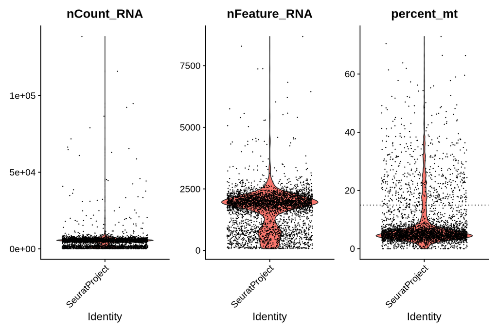

```r
# first calculate the mitochondrial percentage for each cell
dat$percent_mt <- PercentageFeatureSet(dat, pattern="^MT.")
# make violin plots
mt_rna = 15
max_counts = 20000



# Check some feature-feature relationships
# % mt RNA vs n Counts, n Features vs n Counts
# Check some feature-feature relationships
# % mt RNA vs n Counts, n Features vs n Counts
VlnPlot(dat, features = c("nCount_RNA", "nFeature_RNA", "percent_mt"))  + geom_hline(yintercept=mt_rna, linetype = "dotted")
```

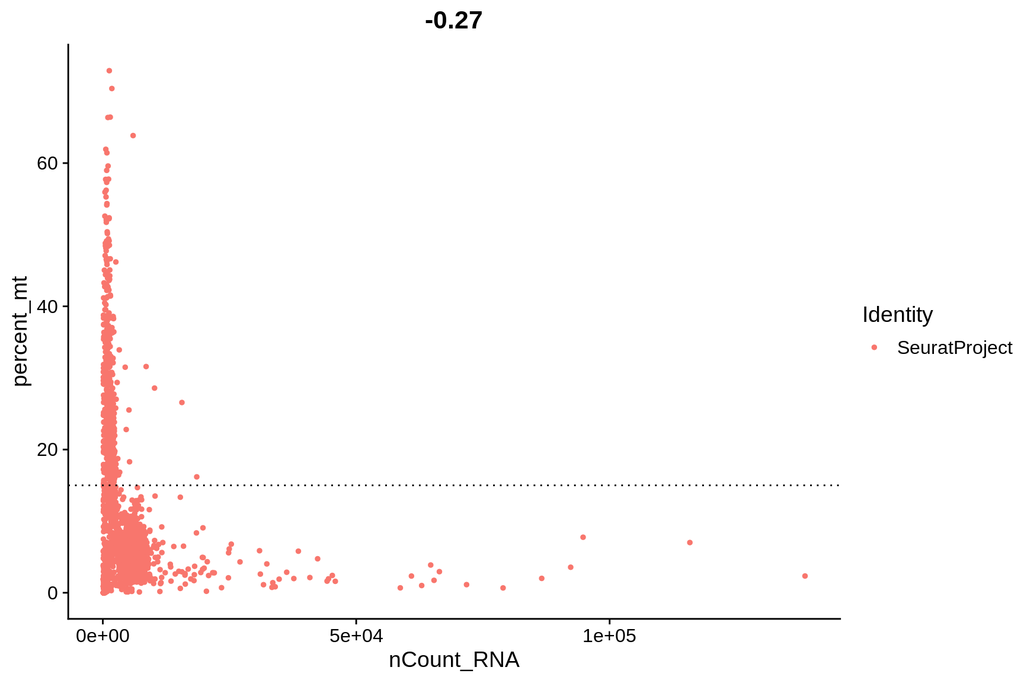

```r
plot1 <- FeatureScatter(dat, feature1 = "nCount_RNA", feature2 = "percent_mt")
plot1 <- plot1 + geom_hline(yintercept=mt_rna, linetype = "dotted")
plot2 <- FeatureScatter(dat, feature1 = "nCount_RNA", feature2 = "nFeature_RNA")
plot2 <- plot2 + geom_vline(xintercept = max_counts, linetype = "dotted")
plot1
```

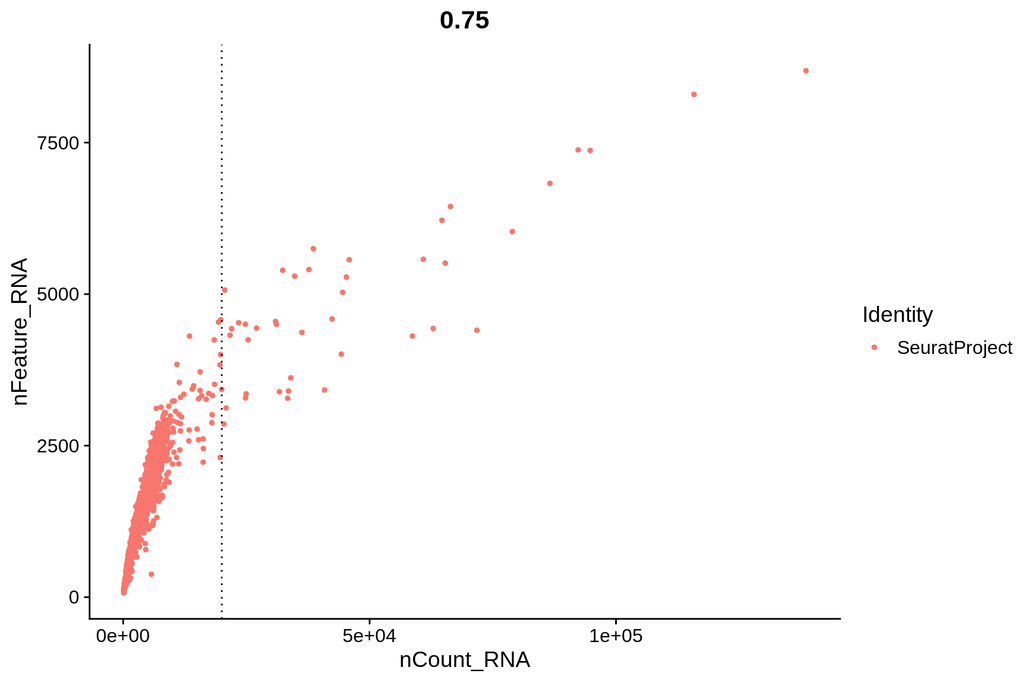

```
##  cells retained by mt RNA content ( 15 %): 3339
##  percentage of retained cells: 85.73 %
```

```
## cells retained by counts ( 20000 ): 3298
##  percentage of retained cells: 84.67 %
```

```r
plot2
```

Check the distribution of the cells with low counts and control death markers:

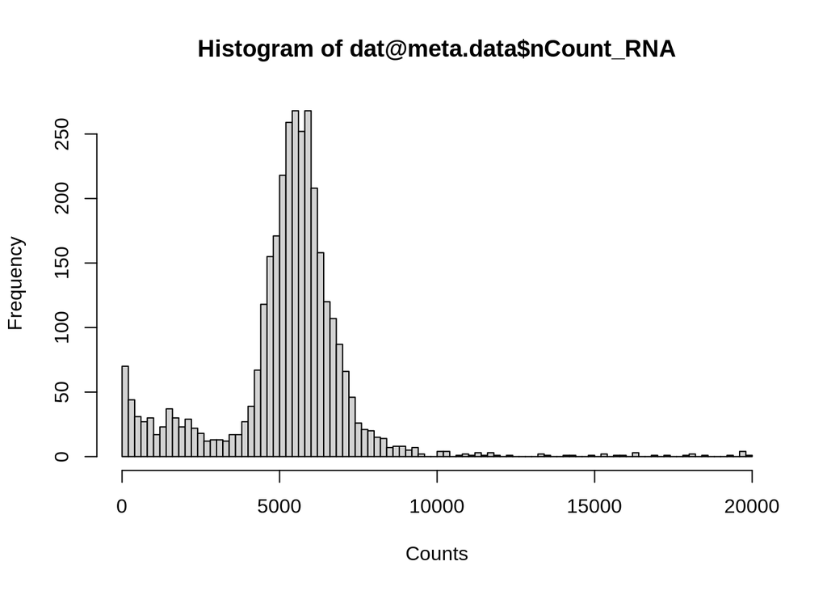

```r
min_counts = 200


hist(dat@meta.data$nCount_RNA, breaks = 100, xlab = "Counts")
```

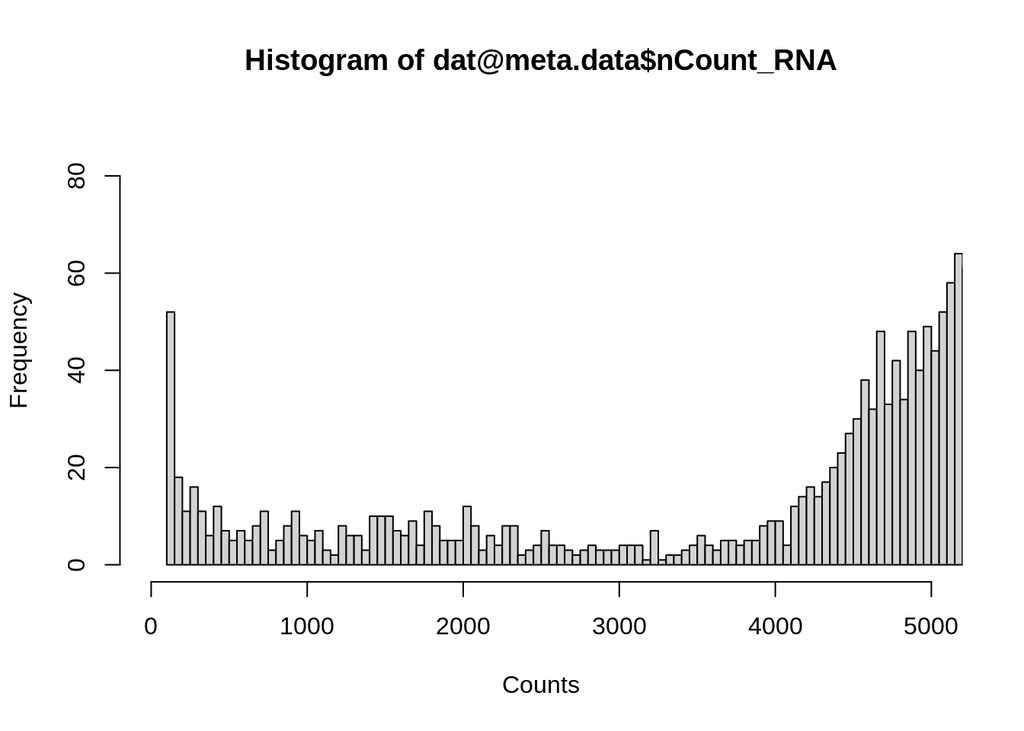

```r
hist(dat@meta.data$nCount_RNA, breaks = 500, xlab = "Counts", xlim = c(0,5000))
```

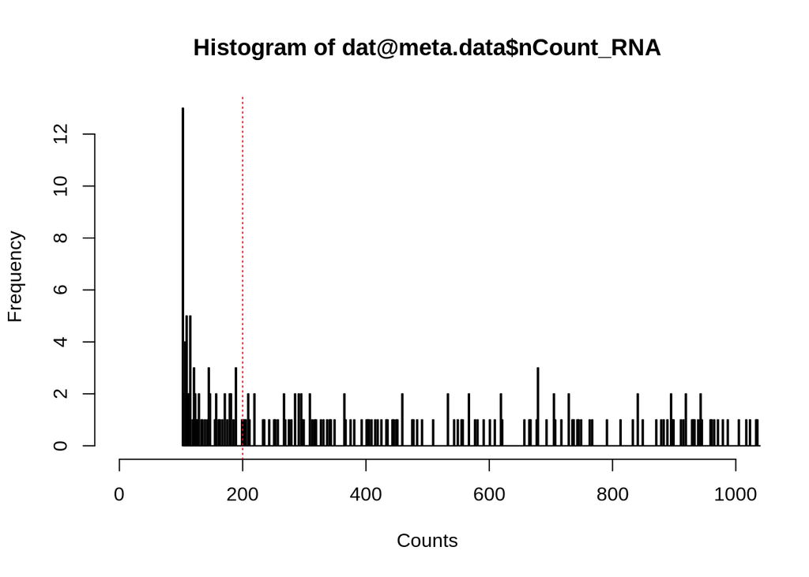

```r
hist(dat@meta.data$nCount_RNA, breaks = 10000, xlab = "Counts", xlim = c(0,1000))
abline(v=min_counts, col="red", lty = 3)
```

The evident peak of cells with < 200 counts could contain dying cells.

```
##    MALAT1    TMSB4X MTRNR2L12       B2M     RPLP1     RPL13     RPS27       HBB
## 6.3000000 1.2857143 1.1142857 1.0285714 0.8571429 0.8571429 0.8285714 0.8142857
##      IGKC    EEF1A1    RPL13A     HLA-A     RPL41      CCL5    MT-CO1     RPS19
## 0.7857143 0.7714286 0.7142857 0.6571429 0.6428571 0.6428571 0.6285714 0.6000000
##     RPLP2      PTMA     RPL21      TPT1      RPS8      RPS6      FTH1     RPS29
## 0.5857143 0.5571429 0.5285714 0.5285714 0.5000000 0.5000000 0.4714286 0.4714286
##     RPS28    RPS27A      GNLY     PLCG2     RPL28      RPS2
## 0.4714286 0.4571429 0.4571429 0.4571429 0.4571429 0.4285714
```

```
## cells retained by counts ( 200 ): 3228
##  percentage of retained cells: 82.88 %
```

[figure not shown]

```r
# Subset the dataset to focus only on those cells with low counts
dat.lowcount <- subset(dat, subset = nCount_RNA < min_counts)

# Get the mean of the counts for each gene and sort them decreasing
meanCounts <- rowMeans(GetAssayData(object = dat.lowcount, slot = 'counts'))
meanCounts <- sort(meanCounts, decreasing = T)

# A boxplot can help to observe the distribution of the means
#boxplot(meanCounts)

# Print the most highly expressed genes
head(meanCounts, 30)
```

```r
dir.create("result")
saveRDS(dat, file = "./result/SAMN15892706_clean_QC.Rds")
```

## Feature selection

```r
#Normalize
dat <- NormalizeData(dat)
# Find the first 4000 variabe features
dat <- FindVariableFeatures(dat, selection.method = "vst", nfeatures = 4000)
```

## Data scaling

Set mean expression to 0 and variance across 1 to avoid highly expressed genes drive the forwarding analyses. Since negative expression is meaningless, scaled data are useful only for UMAP and clustering

```r
# scale data, the scaled data are saved in:
# dat[["RNA"]]@scale.data

all.genes <- rownames(dat)

dat <- ScaleData(dat, vars.to.regress = c("percent_mt","nCount_RNA"))
```

## Dimensionality reduction

```r
dat <- RunPCA(dat, features = VariableFeatures(object = dat), verbose = F, seed.use = 1)
print(dat[["pca"]], dims = 1:5, nfeatures = 5)
```

```
## PC_ 1
## Positive:  CCL5, GAPDH, RPS19, GNLY, RPLP1
## Negative:  HIST1H2BJ, HDAC9, HIST2H2BF, TRIB1, HIST1H2BF
## PC_ 2
## Positive:  CD52, GZMH, SH3BGRL3, FGFBP2, KLRC2
## Negative:  HILPDA, REL, NFKBIA, TNFRSF18, RELB
## PC_ 3
## Positive:  SPI1, IFNGR2, CSTA, LYZ, AIF1
## Negative:  CLEC2B, KLRC3, STK17A, BTG1, ID2
## PC_ 4
## Positive:  FCER1G, ENO1, RAMP1, TMIGD2, CD7
## Negative:  HSPH1, HSPA1A, HSP90AA1, DNAJB1, HSPA1B
## PC_ 5
## Positive:  P4HA1, KLRC3, PKM, MIF, GAPDH
## Negative:  UBB, HSP90AA1, HSPA1A, DNAJB1, HSP90AB1
```

## UMAP

UMAP is a graph-based method of clustering. The first step in this process is to construct a KNN graph based on the euclidean distance in PCA space:

```r
dat <- FindNeighbors(dat, dims = 1:20)
```

The graph now can be used as input for the function `runUMAP()`

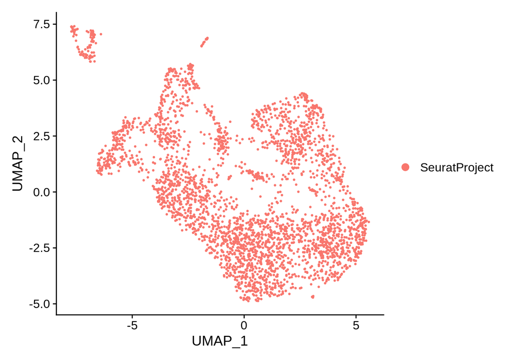

```r
dat <- RunUMAP(dat, dims = 1:20, seed.use = 1)
DimPlot(dat, reduction = 'umap', seed = 1)
```

## Final plots:

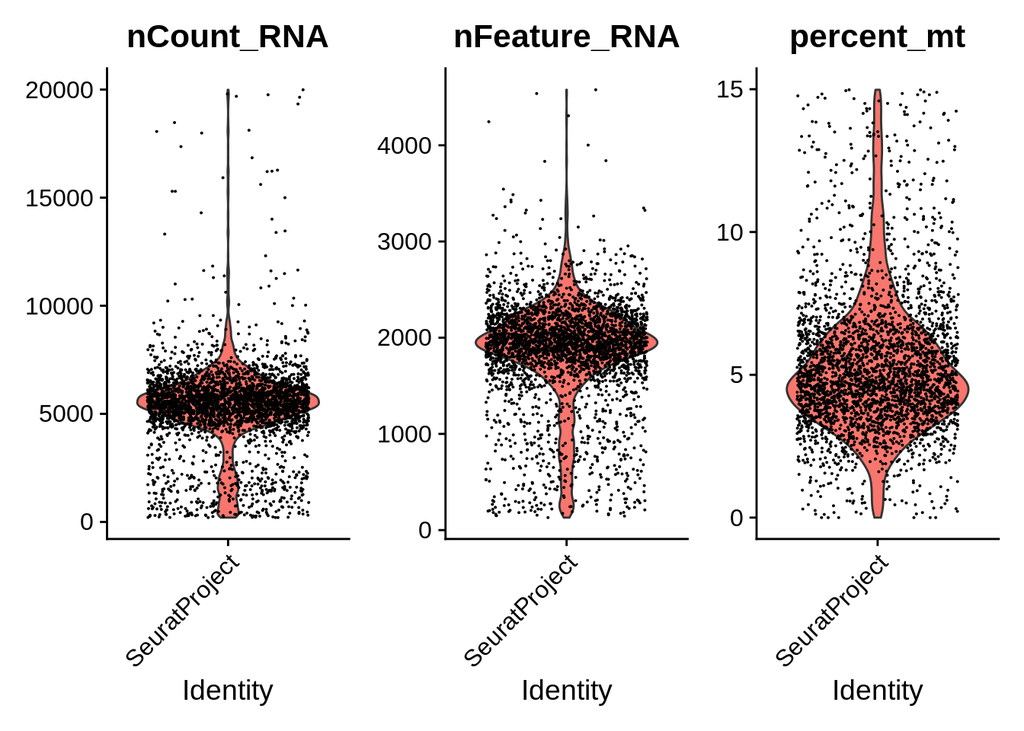

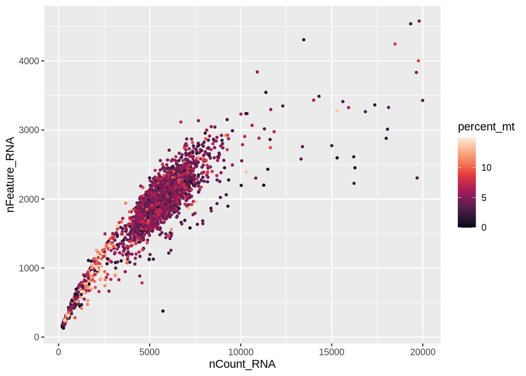

```
## QC metrics
```

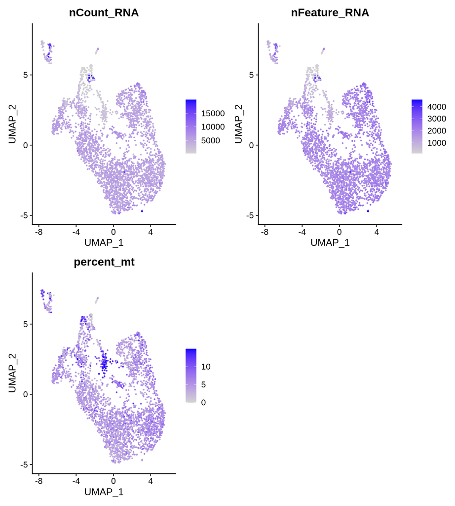

```
## markers
```

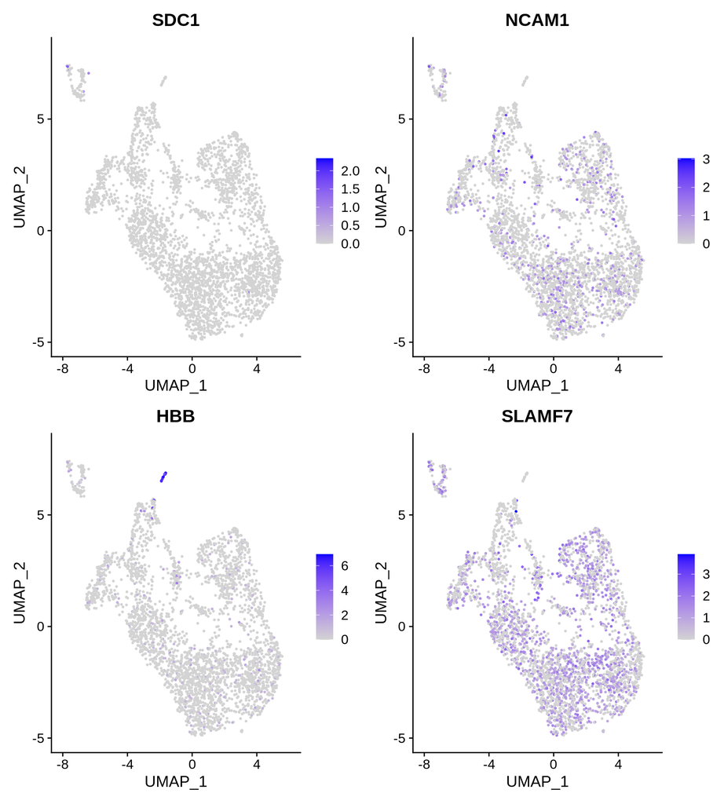